# Data Science Project 2

# Group No.37–

# Student Name: Huanyu Zhou,Student Number:22829755

# Student Name: Hao Li, Student Number: 22297697

# Contribution to each task:

Huanyu Zhou: mainly responsible for classification part and revise clustering part. Hao Li: mainly responsible for clustering part and revise classification part.

# Classification

## 1.Prepare the data

```r
e<- read.csv("C:/Users/HP/Desktop/Y1Semester1/CITS4009 Introduction to Data Science/nat_enrol_1.csv", header=T, sep=",")
```

### 1.1 Data transformation

In this classification, we set “Institution_Type” as our target variable which indicate whether the enrollment is Go8 or not. To make data more suitable for modelling, we change the range of “age” variable, and convert the form of “X_Field_of_Education” and “X_Supp_field_of_education” from integer to factor, change “atar” from factor to numeric.

```r
e$age <- e$age
levels(e$age) <- c("16 and under", "18 to 22","18 to 22","18 to 22","18 to 22","18 to 22","18 to 22","23 to 29","23 to 29","23 to 29","23 to 29","23 to 29","23 to 29","23 to 29","30 to 39","40 to 49","50 to 59"," 60 and over")

e$X_Field_of_Education<-as.factor(e$X_Field_of_Education)
e$X_Supp_field_of_education<-as.factor(e$X_Supp_field_of_education)
e$atar<-as.numeric(e$atar)
```

Since “disability” and “Disability” means the same, “No-Disability”, “no disability” and “No disability” as well, so change variable “disability” to 2 levels. Then these variables should better be dropped: “institution_code,Institution,X,campus_country” variables as they are referring to target variable(Institution_Type) itself. Besides, more than 80 percent of “mceetya_regional_remote_count,asgs_regional_remote_count,onshore_indicator,regionalremote_value” variables are NA, so they cannot be a good indicator for prediction model.“updatewhen,updatewho,id” variables clearly are not related to target variable.

```r
library(dplyr)
e<-select (e,-c(institution_code,Institution,X,campus_country,mceetya_regional_remote_count,asgs_regional_remote_count,onshore_indicator,regionalremote_value,updatewhen,updatewho,id))
levels(e$disability)[levels(e$disability)=="disability"] <- "Disability"
levels(e$disability)[levels(e$disability)=="no disability"] <- "No-Disability"
 levels(e$disability)[levels(e$disability)=="No disability"] <- "No-Disability"
```

### 1.2 Transform “Institution_Type” from factor to integer. “1” means this is a Go8 university and “-1” presents inversely.

```r
e$Institution_Type<- as.character(e$Institution_Type)
e$Institution_Type=ifelse(e$Institution_Type=='Go8 University',1,-1)
e$Institution_Type <-as.integer(e$Institution_Type)
```

## 2.Pre-processing data before modelling

During the code we seperate data into three parts for Training, Calibration and testing, and classify feature variables as categorical variables and numeric variables.

```r
e$rgroup <- runif(dim(e)[[1]])
eTrainAll <- subset(e,rgroup<=0.9)
eTest <- subset(e,rgroup>0.9)
outcome <- 'Institution_Type'
vars <- setdiff(colnames(eTrainAll), c(outcome,'rgroup'))
catVars <- vars[sapply(eTrainAll[,vars],class) %in%
c('factor','character')]
numericVars <- vars[sapply(eTrainAll[,vars],class) %in%
c('numeric','integer')]
pos <- '1'

useForCal <- rbinom(n=dim(eTrainAll)[[1]],size=1,prob=0.1)>0
eCal <- subset(eTrainAll,useForCal)
eTrain <- subset(eTrainAll,!useForCal)
```

## 3. Build single-variate models

### 3.1 Model building for single categorical variable

#### 3.1.1 Build predict function to repeat

```r
mkPredC <- function(outCol,varCol,appCol) {
pPos <- sum(outCol==pos)/length(outCol)
naTab <- table(as.factor(outCol[is.na(varCol)]))
pPosWna <- (naTab/sum(naTab))[pos]
vTab <- table(as.factor(outCol),varCol)
pPosWv <- (vTab[pos,]+1.0e-3*pPos)/(colSums(vTab)+1.0e-3)
pred <- pPosWv[appCol]
pred[is.na(appCol)] <- pPosWna
pred[is.na(pred)] <- pPos
pred
}
```

#### 3.1.2 Using predict function go through all categorical variables to get prediction for single variable

```r
for(v in catVars) {
pi <- paste('pred',v,sep='')
eTrain[,pi] <- mkPredC(eTrain[,outcome],
eTrain[,v],eTrain[,v])
eCal[,pi] <- mkPredC(eTrain[,outcome],
eTrain[,v],eCal[,v])
eTest[,pi] <- mkPredC(eTrain[,outcome],
eTrain[,v],eTest[,v])
}
```

### 3.3 Evaluate model of single categorical variable

```r
library('ROCR')
calcAUC <- function(predcol,outcol) {
perf <- performance(prediction(predcol,outcol==pos),'auc')
as.numeric(perf@y.values)
}

for(v in catVars) {
pi <- paste('pred',v,sep='')
aucTrain <- calcAUC(eTrain[,pi],eTrain[,outcome])
if(aucTrain>=0.7) {
aucCal <- calcAUC(eCal[,pi],eCal[,outcome])
print(sprintf(
"%s, trainAUC: %4.3f calibrationAUC: %4.3f",
pi, aucTrain, aucCal))
} }
```

```
## [1] "predNarrow_FOE, trainAUC: 0.718 calibrationAUC: 0.711"
## [1] "predperm_home_post, trainAUC: 0.719 calibrationAUC: 0.695"
## [1] "predX_Field_of_Education, trainAUC: 0.765 calibrationAUC: 0.750"
## [1] "predPerm_Home_Postcode_Description, trainAUC: 0.705 calibrationAUC: 0.687"
```

These four categorical variables’ trainAUC are all around 0.7 and only slightly higher than their calibrationAUC which indicate these four single vatiable models are not overfitting and could be promising variables.

### 3.2 Building single numerical Variable models and evaluate them

Despite the prediction function is different to categorical variable, the steps are same.

```r
mkPredN <- function(outCol,varCol,appCol) {
cuts <- unique(as.numeric(
quantile(varCol, probs=seq(0, 1, 0.1),na.rm=T)))
varC <- cut(varCol,cuts)
appC <- cut(appCol,cuts)
mkPredC(outCol,varC,appC)
}
for(v in numericVars) {
pi<-paste('pred',v,sep='')
eTrain[,pi]<-mkPredN(eTrain[,outcome],eTrain[,v],eTrain[,v])
eTest[,pi]<-mkPredN(eTrain[,outcome],eTrain[,v],eTest[,v])
eCal[,pi]<-mkPredN(eTrain[,outcome],eTrain[,v],eCal[,v])
aucTrain<-calcAUC(eTrain[,pi],eTrain[,outcome])
if(aucTrain>=0.55) {
aucCal<-calcAUC(eCal[,pi],eCal[,outcome])
print(sprintf(
"%s, trainAUC: %4.3f calibrationAUC: %4.3f",
pi,aucTrain,aucCal))
} }
```

```
## [1] "predatar, trainAUC: 0.585 calibrationAUC: 0.583"
```

According this data, trainAUC only performs slightly better than random guess.

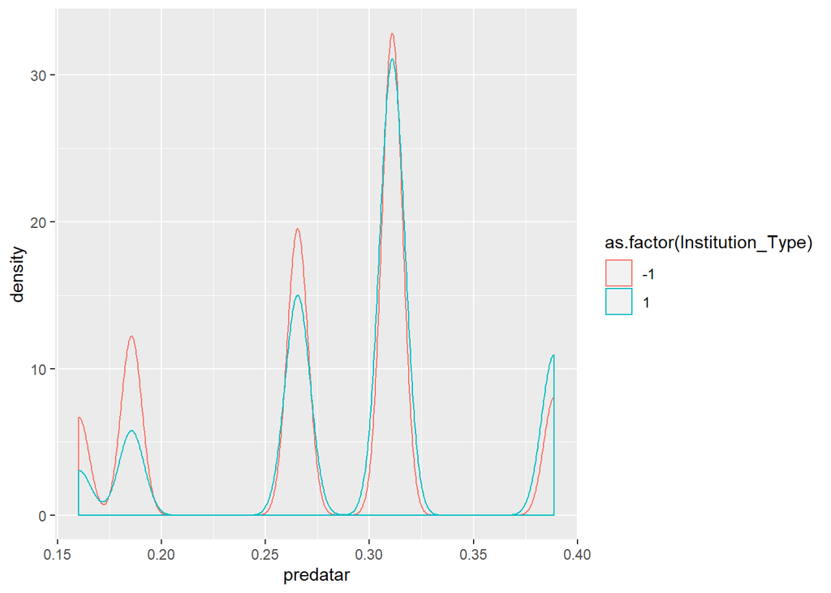

```r
library(ggplot2)
ggplot(data=eCal) +
geom_density(aes(x=predatar,color=as.factor(Institution_Type)))
```

The double density plot presents one of the two lines is almost exactly covering each other, only can say maybe the atar of the enrolment for not Go8 university is lower.

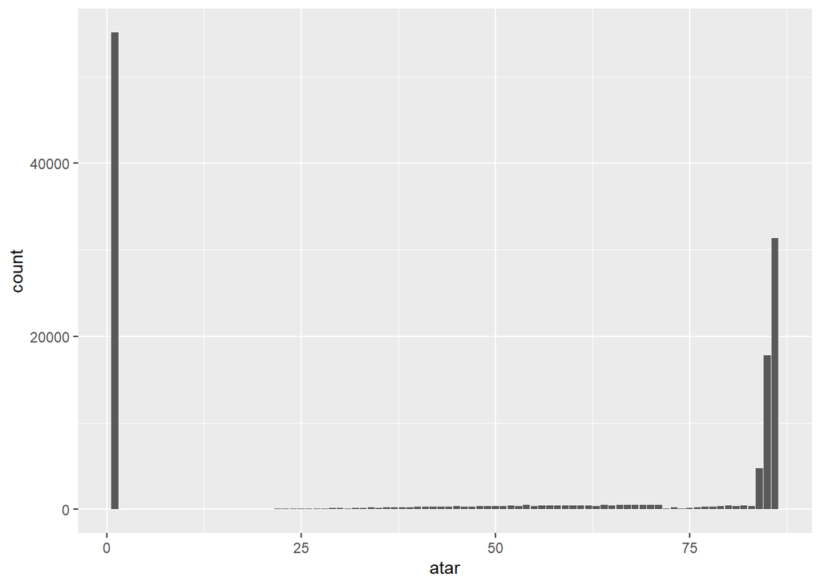

```r
ggplot(data=e)+geom_bar(aes(x=atar))
```

This barchart has explained why it is not a good feature variable: most atar data is either 1 or above 80.

### 3.3 Cross-validation to evaluate model

Using cross-validation to estimate effects of overfitting

```r
aucs <- rep(0,100)
aucsfunc <- function(var) {for(rep in 1:length(aucs)) {
useForCalRep<-rbinom(n=nrow(eTrainAll),size=1,prob=0.1)>0
predRep<-mkPredC(eTrainAll[!useForCalRep,outcome],
eTrainAll[!useForCalRep,var],
eTrainAll[useForCalRep,var])
aucs[rep]<-calcAUC(predRep,eTrainAll[useForCalRep,outcome])
}
print(sprintf("%s, mean of aucs: %4.3f sd of aucs: %4.3f",
var,mean(aucs),sd(aucs)))}
prevar<-c('Narrow_FOE','Perm_Home_Postcode_Description','perm_home_post','X_Field_of_Education')
for(i in prevar){aucsfunc(i)}
```

```
## [1] "Narrow_FOE, mean of aucs: 0.717 sd of aucs: 0.004"
## [1] "Perm_Home_Postcode_Description, mean of aucs: 0.679 sd of aucs: 0.006"
## [1] "perm_home_post, mean of aucs: 0.689 sd of aucs: 0.005"
## [1] "X_Field_of_Education, mean of aucs: 0.760 sd of aucs: 0.004"
```

The four categorical variables’ mean of AUC are fairly good, and their standard deviance are pretty low as well, so the 100-fold replicated estimate cross-validation proves the models do not have serious overfitting situation.

## 4.Multi-variable models

#### 4.1.1 Feature Selection for decision tree

```r
logLikelyhood <- function(outCol,predCol) {
sum(ifelse(outCol==pos,log(predCol),log(1-predCol)))
}

baseRateCheck <-
logLikelyhood(
eCal[,outcome],
sum(eCal[,outcome]==pos)/length(eCal[,outcome])
)
baseRateCheck
```

```
## [1] -6937.709
```

Then use loglikelyhood function to run through categorical variables to pick features based on a deviance improvement.

```r
selVars <- c()
minStep <- 5
for(v in catVars) {
pi <- paste('pred',v,sep='')
liCheck <- 2*((logLikelyhood(eCal[,outcome],eCal[,pi])
- baseRateCheck))
if(liCheck>minStep) {
print(sprintf("%s, calibrationScore: %g",pi,liCheck))
selVars <- c(selVars,pi)
} }
```

```
## [1] "predstate, calibrationScore: 754.077"
## [1] "predbroad_course_type, calibrationScore: 137.908"
## [1] "predcourse_type, calibrationScore: 305.631"
## [1] "predage, calibrationScore: 113.61"
## [1] "predindigenous, calibrationScore: 9.96801"
## [1] "predattendance_type, calibrationScore: 88.9912"
## [1] "predattendance_mode, calibrationScore: 753.031"
## [1] "predbroad_foe, calibrationScore: 447.66"
## [1] "predNarrow_FOE, calibrationScore: 1404"
## [1] "predperm_home_post, calibrationScore: 664.98"
## [1] "predperm_home_country, calibrationScore: 17.3909"
## [1] "predbasis_for_admission, calibrationScore: 338.819"
## [1] "predspecial_course, calibrationScore: 356.293"
## [1] "predcountry_of_birth, calibrationScore: 227.735"
## [1] "predhighest_ed_attainment, calibrationScore: 254.676"
## [1] "predperm_home_res, calibrationScore: 22.677"
## [1] "predsupp_broad_foe, calibrationScore: 44.512"
## [1] "predSES, calibrationScore: 138.338"
## [1] "predX_Field_of_Education, calibrationScore: 1921.13"
## [1] "predX_Supp_field_of_education, calibrationScore: 422.074"
## [1] "predcourse_name, calibrationScore: 2181.76"
## [1] "prednesb, calibrationScore: 13.8824"
## [1] "predRegional, calibrationScore: 117.565"
## [1] "predRegion, calibrationScore: 26.6977"
## [1] "predATAR_Group, calibrationScore: 444.905"
## [1] "predPerm_Home_Postcode_Description, calibrationScore: 651.451"
## [1] "predAustralian_Region, calibrationScore: 240.994"
```

Use loglikelyhood function to run through numeric variables

```r
for(v in numericVars) {
pi <- paste('pred',v,sep='')
liCheck <- 2*((logLikelyhood(eCal[,outcome],eCal[,pi])
- baseRateCheck) - 1)
if(liCheck>=minStep) {
print(sprintf("%s, calibrationScore: %g", pi,liCheck))
selVars <- c(selVars,pi)
} }
```

```
## [1] "predatar, calibrationScore: 230.005"
```

#### 4.1.2 Use selected features to build decision tree and evaluate it with AUC

```r
library('rpart')
f <- paste(outcome,'>0 ~ ',paste(selVars,collapse=' + '),sep='')
tmodel <- rpart(f,data=eTrain,
control=rpart.control(cp=0.001,minsplit=1000,
minbucket=1000,maxdepth=5))
print(calcAUC(predict(tmodel,newdata=eTrain),eTrain[,outcome]))
```

```
## [1] 0.8659089
```

```r
print(calcAUC(predict(tmodel,newdata=eTest),eTest[,outcome]))
```

```
## [1] 0.8439651
```

```r
print(calcAUC(predict(tmodel,newdata=eCal),eCal[,outcome]))
```

```
## [1] 0.838559
```

AUC of this decision tree model for Train, Calibration and test performs are very high, this proves the model is performing very well.

```r
print(tmodel)
```

```
## n= 104520
##
## node), split, n, deviance, yval
##       * denotes terminal node
##
##  1) root 104520 21108.30000 0.280807500
##    2) predcourse_name< 0.5811199 97994 17757.34000 0.237718600
##      4) predX_Field_of_Education< 0.3587617 67373  7967.68200 0.137043000
##        8) predperm_home_post< 0.343772 45670  3427.03300 0.081716660
##         16) predX_Field_of_Education< 0.1947875 29597  1350.06300 0.047910260 *
##         17) predX_Field_of_Education>=0.1947875 16073  1980.85800 0.143968100
##           34) predcourse_name< 0.167554 3280    15.92195 0.004878049 *
##           35) predcourse_name>=0.167554 12793  1885.21100 0.179629500 *
##        9) predperm_home_post>=0.343772 21703  4106.67700 0.253467300
##         18) predcourse_name< 0.04277251 3226    11.95536 0.003719777 *
##         19) predcourse_name>=0.04277251 18477  3858.37200 0.297072000
##           38) predX_Field_of_Education< 0.174201 9056  1436.19000 0.197659000 *
##           39) predX_Field_of_Education>=0.174201 9421  2246.64900 0.392633500 *
##      5) predX_Field_of_Education>=0.3587617 30621  7604.34500 0.459227300
##       10) predperm_home_post< 0.2446002 11722  2163.22500 0.244156300
##         20) predcourse_name< 0.2416683 1988    28.57696 0.014587530 *
##         21) predcourse_name>=0.2416683 9734  2008.47900 0.291041700
##           42) predperm_home_post< 0.09601205 2651   252.78910 0.106752200 *
##           43) predperm_home_post>=0.09601205 7083  1631.95700 0.360016900 *
##       11) predperm_home_post>=0.2446002 18899  4562.61200 0.592623900
##         22) predcourse_name< 0.1211453 1615    38.05820 0.024148610 *
##         23) predcourse_name>=0.1211453 17284  3953.87700 0.645741700
##           46) predattendance_mode< 0.2291401 2179   472.96470 0.318494700 *
##           47) predattendance_mode>=0.2291401 15105  3213.89900 0.692949400 *
##    3) predcourse_name>=0.5811199 6526   437.00660 0.927827200
##      6) predcourse_name< 0.8179821 1229   282.18880 0.642799000 *
##      7) predcourse_name>=0.8179821 5297    31.80668 0.993958800 *
```

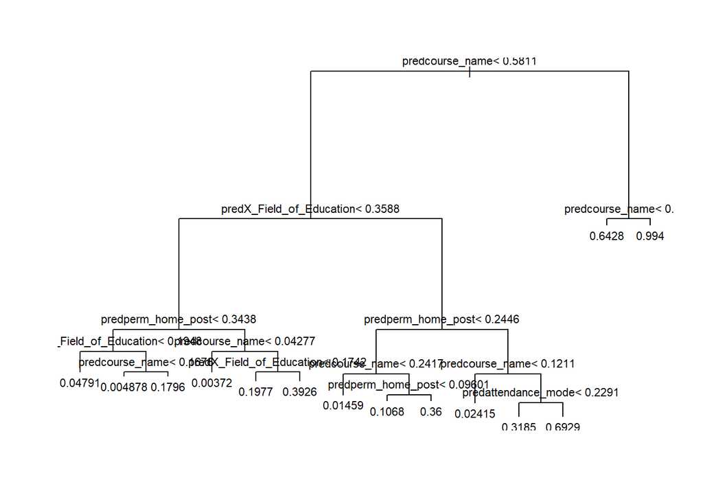

```r
f <- paste(outcome,'>0 ~ ',paste(selVars,collapse=' + '),sep='')
tmodel <- rpart(f,data=eTrain,
control=rpart.control(cp=0.001,minsplit=1000,
minbucket=1000,maxdepth=5))
par(cex=0.7)
plot(tmodel)
text(tmodel)
```

### 4.2 Build Naive Baye model

```r
pPos <- sum(eTrain[,outcome]==pos)/length(eTrain[,outcome])
nBayes <- function(pPos,pf) {
pNeg <- 1 - pPos
smoothingEpsilon <- 1.0e-5
scorePos <- log(pPos + smoothingEpsilon) +
rowSums(log(pf/pPos + smoothingEpsilon))
scoreNeg <- log(pNeg + smoothingEpsilon) +
rowSums(log((1-pf)/(1-pPos) + smoothingEpsilon))
m <- pmax(scorePos,scoreNeg)
expScorePos <- exp(scorePos-m)
expScoreNeg <- exp(scoreNeg-m)
expScorePos/(expScorePos+expScoreNeg)
}
```

```r
pVars <- paste('pred',c(numericVars,catVars),sep='')
eTrain$nbpredl <- nBayes(pPos,eTrain[,pVars])
eCal$nbpredl <- nBayes(pPos,eCal[,pVars])
eTest$nbpredl <- nBayes(pPos,eTest[,pVars])
print(calcAUC(eTrain$nbpredl,eTrain[,outcome]))
```

```
## [1] 0.9055006
```

```r
print(calcAUC(eCal$nbpredl,eCal[,outcome]))
```

```
## [1] 0.8785274
```

```r
print(calcAUC(eTest$nbpredl,eTest[,outcome]))
```

```
## [1] 0.8832764
```

## 5. Conclusion of classification

Two multiple variable models have higher calculated AUCs(Train,Calibration,Test) than all single variable models, it indicates we should choose multiple variable model for classification. After comparing decision tree and Naive Baye model, according to calculated AUCs(Train,Calibration,Test) for both models, Naive has better performance.

# Clustering

## 1. Prepare data for investigation

```r
e<- read.csv("C:/Users/HP/Desktop/Y1Semester1/CITS4009 Introduction to Data Science/nat_enrol_1.csv", header=T, sep=",")
e$age <- e$age
levels(e$age) <- c("16 and under", "18 to 22","18 to 22","18 to 22","18 to 22","18 to 22","18 to 22","23 to 29","23 to 29","23 to 29","23 to 29","23 to 29","23 to 29","23 to 29","30 to 39","40 to 49","50 to 59"," 60 and over")
```

Narrow down dataset with intuitive feature variables

```r
library(dplyr)
eclu<-select (e,c(state,Institution_Type,broad_course_type,age,overseas,broad_foe,attendance_type))
```

Take out “state” variable as label, transfer other categorical variables to numeric variables.

```r
esta<-eclu[,1,drop=FALSE]
eclu<-eclu[,-1]
for(i in 1:ncol(eclu)) {eclu[,i]=as.numeric(eclu[,i])}
eclu<-cbind(eclu,esta)
```

As the original dataset is too large, here subset dataset first for clustering.

```r
useForclu <- rbinom(n=dim(eclu)[[1]],size=1,prob=0.003)>0
eclusam <- subset(eclu,useForclu)
```

prepare scaled dataset(pmatrix) for clustering

```r
vars.to.use <- colnames(eclusam)[-7]
pmatrix <- scale(eclusam[,vars.to.use])
pcenter <- attr(pmatrix, "scaled:center")
pscale <- attr(pmatrix, "scaled:scale")
```

## 2.Build clustering model

### 2.1 calculate distance

As this dataset are all categorical variables, here is the function to calculate hamming distance and use as.dist() to transfer the calculated distance.

```r
hamming_loop <- function(X) {
    d <- matrix(0, nrow = nrow(X), ncol = nrow(X))
    for ( i in 1:(nrow(X) - 1) ) {
        for ( j in (i + 1):nrow(X) ) {
            d[i,j] <- d[j,i] <- sum(X[i,] != X[j,])  }   }
    d}
d<-hamming_loop(pmatrix)
d<- as.dist(d)
```

### 2.2Plotting dendrogram

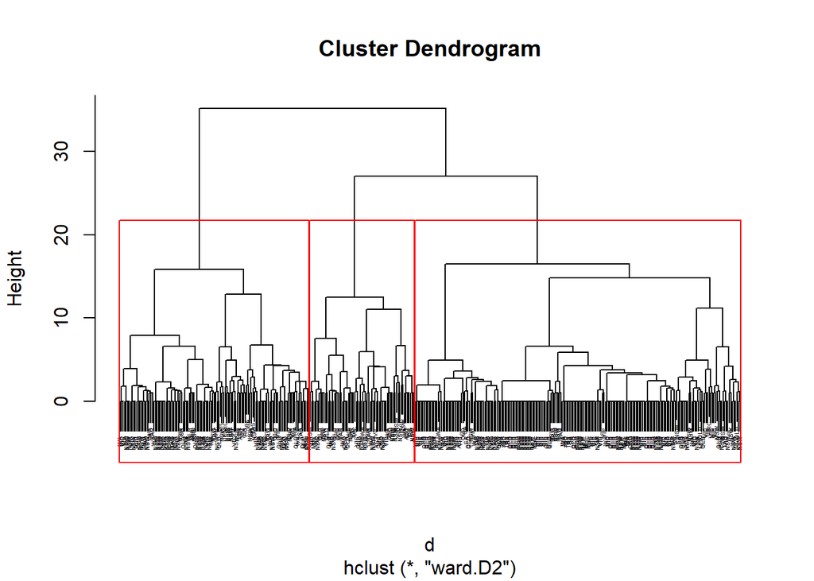

```r
pfit <- hclust(d, method="ward.D2")
plot(pfit, labels=eclusam$state,hang = 0.1, cex = 0.3)
rect.hclust(pfit, k=3)
```

During this clustering, we suppose k is corresponding to “Institution Type”, so make k=3. There are too many partitions to make lable visible, may caused by the dataset itself has too many layers.

Extract members of each cluster using cutree()

```r
groups <- cutree(pfit, k=3)
print_clusters <- function(labels, k) {
for(i in 1:k) {
print(paste("cluster", i))
print(eclusam[labels==i,
vars.to.use])
} }
print_clusters(groups, 3)
```

```
## [1] "cluster 1"
##        Institution_Type broad_course_type age overseas broad_foe
## 46                    2                 3   2        1        13
## 454                   2                 3   2        1        10
## 1003                  2                 2   3        1        13
## 1061                  2                 3   2        1        13
## 1523                  2                 3   2        1         8
## 4449                  3                 3   4        1         9
## 4733                  3                 3   2        1         3
## 6727                  3                 3   2        1         8
## 8456                  3                 2   3        1         5
## 8909                  3                 3   2        1        13
## 9213                  3                 3   2        1        13
## 9636                  3                 3   2        1         8
## 10171                 3                 2   4        1        13
```

[output cut: 798 more lines]

Most enrollments of Group 1 and Group2 are domestic students. Group 3 almost all enrollments are international students(oversea 2) and Institution_Type has no Type1(“college”)

### 2.3 Visualising Cluster with ggplot

```r
library(ggplot2)
# Calculate the principle components of pmatrix
princ <- prcomp(pmatrix)
nComp <- 2
project <- as.data.frame(predict(princ, newdata=pmatrix)[,1:nComp])
project.plus <-
cbind(project,
cluster=as.factor(groups),
state=eclusam$state)
```

```r
library('grDevices')
h <- do.call(
rbind,
lapply(
unique(groups),
function(c) {
f <- subset(project.plus,cluster==c);
f[chull(f),]
} ) )
```

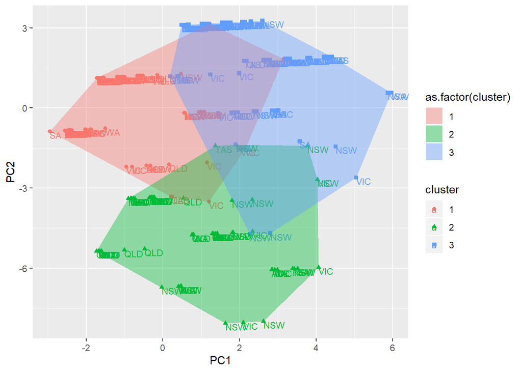

```r
p <- ggplot(project.plus, aes(x=PC1, y=PC2)) +
geom_point(aes(shape=cluster, color=cluster)) +
geom_text(aes(label=state, color=cluster),
hjust=0, vjust=1, size=3) +
geom_polygon(data=h,
aes(group=cluster,
fill=as.factor(cluster)),
alpha=0.4,linetype=0)
p
```

Though three clusters are covering each other at few part, most of them are well seperated.

### 2.4 Judging the stability of a clustering algorithm

```r
library(fpc)
kbest.p <- 3
cboot.hclust <- clusterboot(
pmatrix, clustermethod=hclustCBI,
method="ward.D2", k=kbest.p)
```

[output not shown]

[output cut: 45 more lines]

[output not shown]

```r
summary(cboot.hclust$result)
```

```
##               Length Class  Mode
## result          7    hclust list
## noise           1    -none- logical
## nc              1    -none- numeric
## clusterlist     3    -none- list
## partition     402    -none- numeric
## clustermethod   1    -none- character
## nccl            1    -none- numeric
```

```r
1-cboot.hclust$bootbrd/100
```

```
## [1] 0.98 0.98 0.98
```

## 3.Selecting K

Function to calculate squared distance

```r
sqr_edist <- function(x, y) {
sum((x-y)^2) }
## Fucntion to calculate WSS of a cluster
wss.cluster <- function(clustermat) {
c0 <- apply(clustermat, 2, FUN=mean)
sum(apply(clustermat, 1,
FUN=function(row){sqr_edist(row,c0)}))
}
```

Function to count WSS

```r
wss.total <- function(dmatrix, labels) {
wsstot <- 0
k <- length(unique(labels))
for(i in 1:k){
wsstot <- wsstot +
wss.cluster(subset(dmatrix, labels==i))
}
wsstot
}
```

Function to calculate total sum of squares(considered as K=1)

```r
totss <- function(dmatrix) {
grandmean <- apply(dmatrix, 2, FUN=mean)
sum(apply(dmatrix, 1,
FUN=function(row){
sqr_edist(row, grandmean)
} ) ) }
```

Function to calculate CH Index

```r
ch_criterion <- function(dmatrix, kmax, method="kmeans") {
if(!(method %in% c("kmeans", "hclust"))){
stop("method must be one of c('kmeans', 'hclust')") }
npts <- dim(dmatrix)[1] # number of rows.
totss <- totss(dmatrix)
wss <- numeric(kmax)
crit <- numeric(kmax)
wss[1] <- (npts-1)*sum(apply(dmatrix, 2, var))
for(k in 2:kmax) {
if(method=="kmeans") {
clustering<-kmeans(dmatrix, k, nstart=10, iter.max=100)
wss[k] <- clustering$tot.withinss
}else { # hclust
d<-hamming_loop(dmatrix)#hamming loop for categorical variables
d<-as.dist(d)
pfit <- hclust(d, method="ward.D2")
labels <- cutree(pfit, k=k)
wss[k] <- wss.total(dmatrix, labels)
} }
bss <- totss - wss
crit.num <- bss/(0:(kmax-1))
crit.denom <- wss/(npts - 1:kmax)
list(crit = crit.num/crit.denom, wss = wss, totss = totss)
}
```

Code to plot the two indicies

```r
library(reshape2)
clustcrit <- ch_criterion(pmatrix, 10, method="hclust")
critframe <- data.frame(k=1:10, ch=scale(clustcrit$crit),
wss=scale(clustcrit$wss))
critframe <- melt(critframe, id.vars=c("k"),
variable.name="measure",
value.name="score")
p<-ggplot(critframe, aes(x=k, y=score, color=measure)) +
geom_point(aes(shape=measure)) +
geom_line(aes(linetype=measure)) +
scale_x_continuous(breaks=1:10, labels=1:10)
```

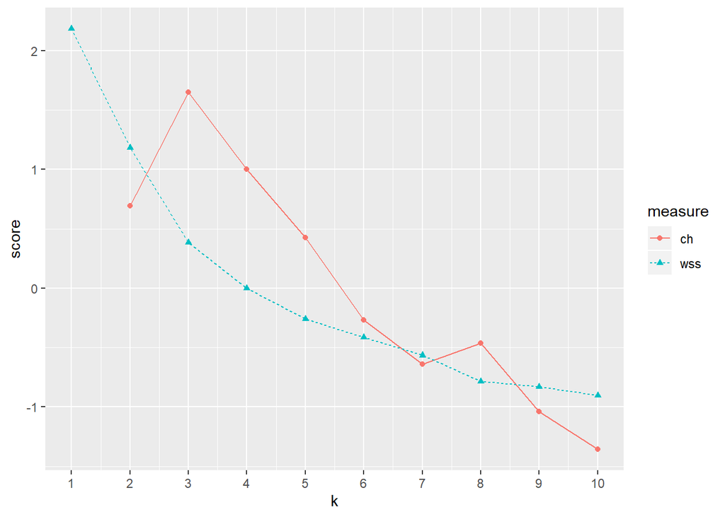

```r
p
```

### 3.2 kmeans for selecting K

```r
pclusters <- kmeans(pmatrix, kbest.p,
nstart=100, iter.max=100)
summary(pclusters)
```

```
##              Length Class  Mode
## cluster      402    -none- numeric
## centers       18    -none- numeric
## totss          1    -none- numeric
## withinss       3    -none- numeric
## tot.withinss   1    -none- numeric
## betweenss      1    -none- numeric
## size           3    -none- numeric
## iter           1    -none- numeric
## ifault         1    -none- numeric
```

From the summary we see that kmeans function automatically calculated the center,totss withinss, which is more convenient and faster to use.

Then we use kmeansruns() with “ch” and “asw” criteria for picking k to see if the result varies from what we have got before.

```r
clustering.ch <- kmeansruns(
pmatrix, krange=1:10, criterion="ch")
clustering.ch$bestk
```

```
## [1] 3
```

```r
clustering.asw <- kmeansruns(
pmatrix, krange=1:10, criterion="asw")
clustering.asw$bestk
```

```
## [1] 10
```

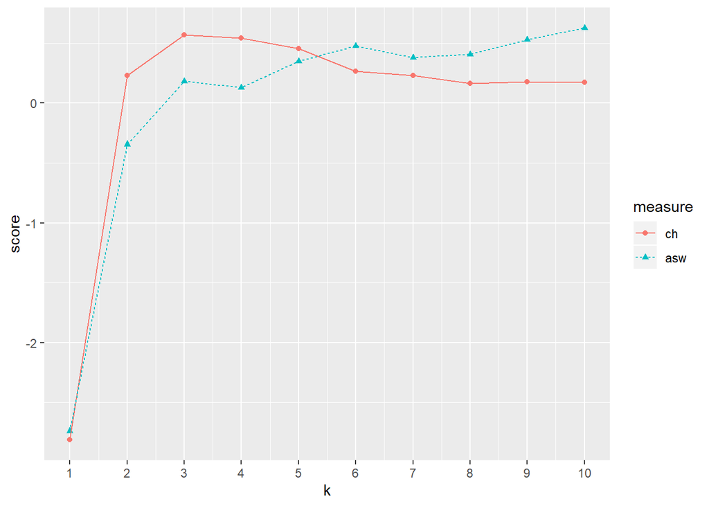

```r
critframe <- data.frame(k=1:10, ch=scale(clustering.ch$crit),
asw=scale(clustering.asw$crit))
critframe <- melt(critframe, id.vars=c("k"),
variable.name="measure",
value.name="score")
p<- ggplot(critframe, aes(x=k, y=score, color=measure)) +
geom_point(aes(shape=measure)) +
geom_line(aes(linetype=measure)) +
scale_x_continuous(breaks=1:10, labels=1:10)
p
```